# Loan Characteristics Exploration

## by Neha Patil

## Investigation Overview

> In this investigation, I wanted to look at the characteristics of loans that could be used to determine status of a loan and the interest rate. The features I focused on are LoanAmount, ProsperRating(credit grade) and Term (time in years).

## Dataset Overview

> This document explores a dataset containing 113937 listed loans with 81 features. LoanStatus and ProsperRating are categorical features, and the rest are numerical. Some of the features are:
> 1. LoanStatus- The phase of the loan. 'Defaulted' -Failure to repay the loan or the interest rate even after the deliquency period. This generally applies to mortgage or national debts. 'Cancelled'- When a debtor is no longer able to pay the loan or has filed for bankcruptcy, they can ask the creditor to cancel the loan. 'Chargedoff'- When a debtor has crossed a set period of deliquency the creditor can charge off the loan but the debt is still valid. This means that loan will not be collected via a traditional method instead it si collected by methods like property seizure and lawsuits.

> 'Past Due (>120 days)','Past Due (91-120 days)','Past Due (61-90 days)','Past Due (31-60 days)','Past Due (16-30 days)','Past Due (1-15 days)'- These are the various deliquency periods of the loan. To keep matters simple I will be referring these as deliquent loans. 'FinalPaymentInProgress'-Loan is almost paid off. 'Current'-Loan is ongoing. 'Completed'>Loan has been paid off.
> 1. ProsperRating- Credit Grade of the debtor. 'HR','E','D','C','B','A','AA': Lowest rating HR and highest rating-AA.
> 2. Term-12,36,60

## Distribution of LoanStatus

> The largest number of loans listed in this dataset are still ongoing (Current). The loan status Completed has the second largest number of count followed by Chargedoff and Defaulted. The delinquency categories of past due are significantly small in number. Two of them -FinalPaymentInProgress and Cancelled are so small in count that they did not get plotted on the graph.

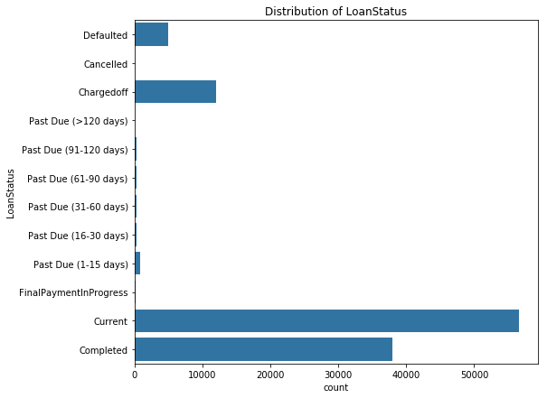

```python
# Univariate plot of LoanStatus
plt.figure(figsize=(8,7))
sb.countplot(data=loan,y='LoanStatus',color=base_color);
plt.title('Distribution of LoanStatus');
```

## Distribution of BorrowerAPR

> The univariate plot of Borrower APR is bimodal in nature with two peaks at 0.2 and 0.36 (approx) respectively. The bulk of the data lies between 0.1 and 0.3 with the count gradually decreasing from 0.25.

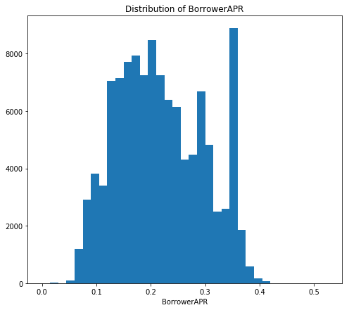

```python
# Univariate plot of BorrowerAPR
plt.figure(figsize=(8,7))
bins=np.arange(0,loan['BorrowerAPR'].dropna().max()+0.015,0.015)
plt.hist(x=loan['BorrowerAPR'].dropna(),bins=bins);
plt.xlabel('BorrowerAPR');
plt.title('Distribution of BorrowerAPR');
```

## Distribution of ProsperRating

> Most of the borrowers have an average credit score ('C'). Most of the borrowers have good credit score with the least numbers being in the extreme end of High Risk(HR) and AA.

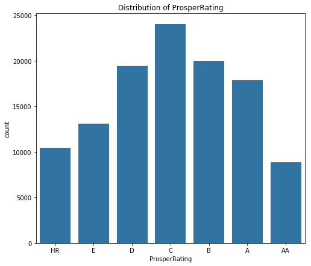

```python
# Univariate plot of ProsperRating
plt.figure(figsize=(8,7))
sb.countplot(data=loan,x='ProsperRating',color=base_color);
plt.title('Distribution of ProsperRating');
```

## Distribution of LoanAmount

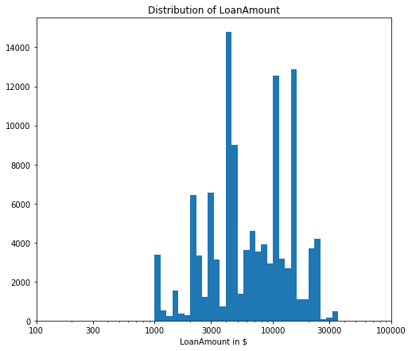

```python
# Univariate plot of LoanOriginalAmount using log transform
plt.figure(figsize=(8,7))
bins=10**np.arange(0,np.log(loan['LoanOriginalAmount'].max())+0.05,0.05)
plt.hist(x=loan['LoanOriginalAmount'],bins=bins);
plt.xscale('log')
plt.xlim(100,100000)
xticks=[100,300,1000,3000,10000,30000,100000]
plt.xticks(xticks,xticks);
plt.xlabel('LoanAmount in $');
plt.title('Distribution of LoanAmount');
```

## BorrowerAPR vs. BorrowerRate

> BorrowerAPR and BorrowerRate have a strong positive correlation. The plot is linear in nature.

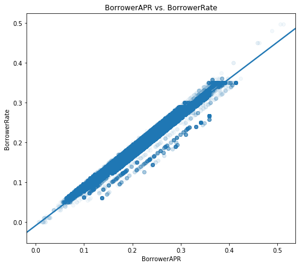

```python
# Bivariate plot between BorrowerAPR and BorrowerRate
plt.figure(figsize=(8,7))
sb.regplot(data=loan,x='BorrowerAPR',y='BorrowerRate',scatter_kws={'alpha':1/20});
plt.title('BorrowerAPR vs. BorrowerRate');
```

## BorrowerAPR, BorrowerRate vs. ProsperRating

> As we can see from the plot that BorrowerAPR and BorrowerRate are strongly correlated to ProsperRating. It is a negative correaltion meaning and the values of ProsperRating increases the value of BorrowerAPR and BorrowerRate decreases.

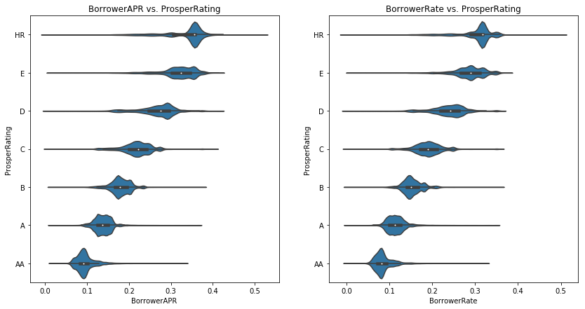

```python
# Bivariate plot between BorrowerAPR, BorrowerRate and ProsperRating
plt.figure(figsize=(14,7))
plt.subplot(1,2,1)
sb.violinplot(data=loan,y='ProsperRating',x='BorrowerAPR',color=base_color);
plt.title('BorrowerAPR vs. ProsperRating');
plt.subplot(1,2,2)
sb.violinplot(data=loan,y='ProsperRating',x='BorrowerRate',color=base_color);
plt.title('BorrowerRate vs. ProsperRating');
```

## LoanStatus vs. ProsperRating

> Defaulted and Chargedoff loan status have more borrower's count in the high risk-fair spectrum of ProsperRating. Loan Status like Current and Completed have more borrower's count in the good-excellent spectrum of ProsperRating

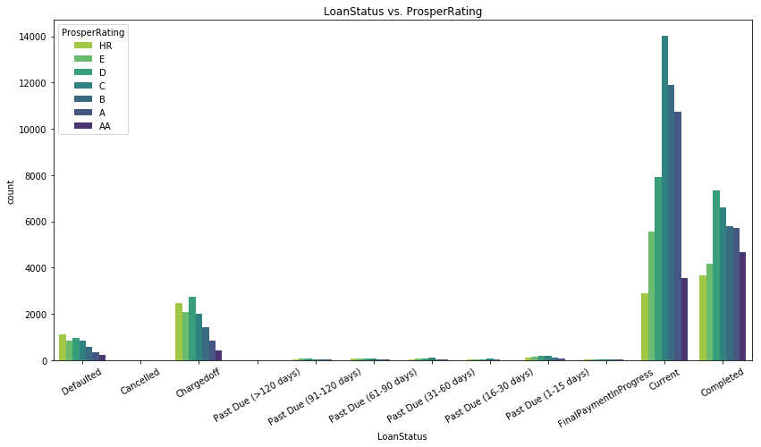

```python
# Bivariate plot between LoanStatus and ProsperRating
plt.figure(figsize=(14,7))
sb.countplot(data=loan,x='LoanStatus',hue='ProsperRating',palette='viridis_r');
plt.xticks(rotation=30);
plt.legend(loc=2,title='ProsperRating');
plt.title('LoanStatus vs. ProsperRating');
```

## LoanStatus vs. BorrowerAPR

> Defaulted, Cancelled, Charged-off and past due loans basically delinquent loans have more BorrowerAPR and BorrowerRate than Current and Completed loans. LoanStatus is dependent on BorrowerAPR and BorrowerRate.

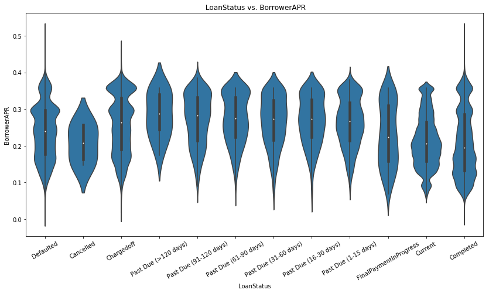

```python
# Bivariate plot between LoanStatus and BorrowerAPR
plt.figure(figsize=(14,7))
sb.violinplot(data=loan,x='LoanStatus',y='BorrowerAPR',color=base_color);
plt.xticks(rotation=30);
plt.title(' LoanStatus vs. BorrowerAPR');
```

## LoanOriginalAmount vs. ProsperRating

> It is clear from the plot that borrowers with high ProsperRating are eligible for high loan amounts. If a borrower has a good Credit Grade then more number of investors will be interested in sponsoring a loan.

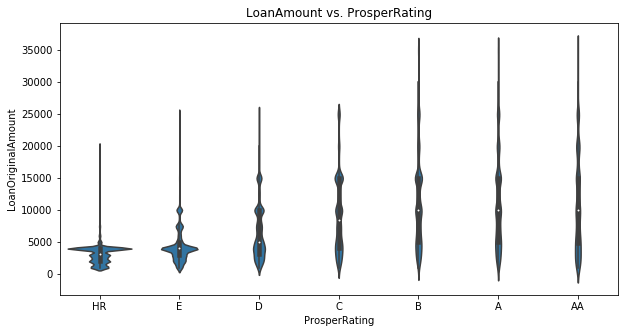

```python
# Bivariate plot between LoanOriginalAmount and ProsperRating
plt.figure(figsize=(10,5))
sb.violinplot(data=loan,x='ProsperRating',y='LoanOriginalAmount',color=base_color);
plt.title('LoanAmount vs. ProsperRating');
```

## BorrowerAPR by LoanStatus and ProsperRating

> It is very clear from the graph that PropserRating has a large influence on BorrowerAPR. It is clear that no matter what the loan status BorrowerAPR will be high for the lower end of ProsperRating scale and will be low for higher end of ProsperRating scale. This trend also holds true for BorrowerRate. The error bars indicate fewer numbers of that particular ProsperRating. Since LoanStatus-Cancelled has very few enteries hence its plot is almost empty. Also in deliquent(past due) status of loans there is less number of the above average ProsperRating compared to the numbers of below average ProsperRating.

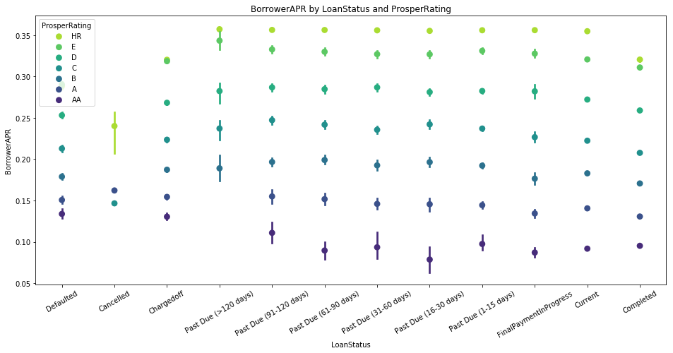

```python
# Pointplot of BorrowerAPR and LoanStatus using ProsperRating as hue
plt.figure(figsize=(16,7))
ax = sb.pointplot(data = loan, x = 'LoanStatus', y = 'BorrowerAPR', hue = 'ProsperRating',
                  linestyles = "",palette='viridis_r');
plt.xticks(rotation=30);
plt.legend(loc=2,title='ProsperRating');
plt.title('BorrowerAPR by LoanStatus and ProsperRating');
```

## LoanAmount by LoanStatus and ProsperRating

> ProsperRating also has an influence on the LoanAmount. Borrowers with higher PropserRating get more number of investors and hence they get more investment as the LoanAmount. We can see that in deliquent (past due) category of loans there are less number (error bars) of borrowers with good ProsperRating.

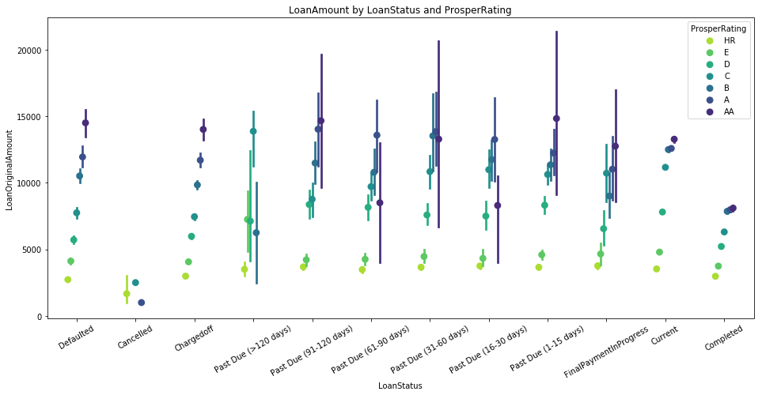

```python
# Pointplot of LoanOriginalAmount and LoanStatus using ProsperRating as hue
plt.figure(figsize=(16,7))
ax = sb.pointplot(data = loan, x = 'LoanStatus', y = 'LoanOriginalAmount', hue = 'ProsperRating',dodge = 0.3,
                  linestyles = "",palette='viridis_r');
plt.xticks(rotation=30);
plt.legend(loc=1,title='ProsperRating');
plt.title('LoanAmount by LoanStatus and ProsperRating');
```

## BorrowerAPR vs. LoanOriginalAmount by ProsperRating

> It becomes more clear with the line plot above as to how much ProsperRating affects features of a loan. There are two loans of different amount-2500 and 15000 dollars respectively. The mind blowing thing is that these two have the same BorrowerAPR. The main reason for this is difference in ProsperRating. The borrower with loan amount of 2500 dollars has HR rating whereas borrower with loan amount of 15000 dollars has AA rating.

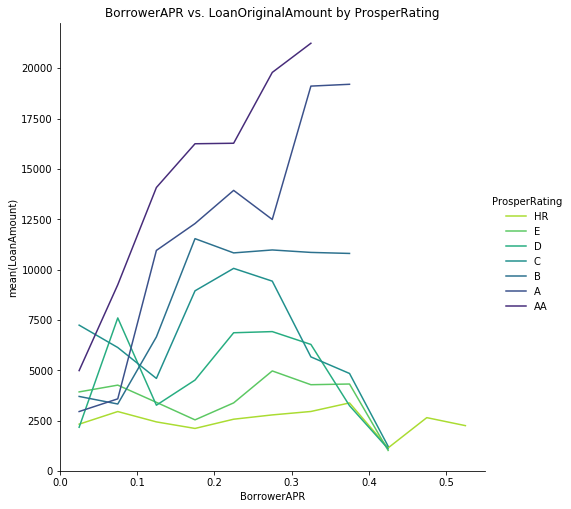

```python
# Lineplot of BorrowerAPR and LoanOriginalAmount using ProsperRating as hue
bin_edges = np.arange(0, loan['BorrowerAPR'].max()+0.05, 0.05)
g = sb.FacetGrid(data = loan, hue = 'ProsperRating',size=7,palette='viridis_r');
g.map(mean_poly, "BorrowerAPR", "LoanOriginalAmount", bins = bin_edges);
g.set_ylabels('mean(LoanAmount)');
g.add_legend();
plt.title('BorrowerAPR vs. LoanOriginalAmount by ProsperRating');
```

## BorrowerAPR vs. LoanOriginalAmount by Term

> As we have already seen BorrowerAPR and LoanAmount also depend on Term. LoanAmount has a directly proportional realtionship with Term - more the length of Term more the LoanAmount. BorrowerAPR has an inversely porportional relationship with Term - more the length of the Term less the BorrowerAPR.

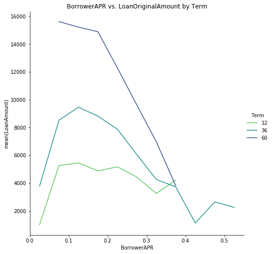

```python
# Lineplot of BorrowerAPR and LoanOriginalAmount using Term as hue
bin_edges = np.arange(0, loan['BorrowerAPR'].max()+0.05, 0.05)
g = sb.FacetGrid(data = loan, hue = 'Term',size=7,palette='viridis_r');
g.map(mean_poly, "BorrowerAPR", "LoanOriginalAmount", bins = bin_edges);
g.set_ylabels('mean(LoanAmount)');
g.add_legend();
plt.title('BorrowerAPR vs. LoanOriginalAmount by Term');
```

## BorrowerAPR vs. LoanOriginalAmount by LoanStatus

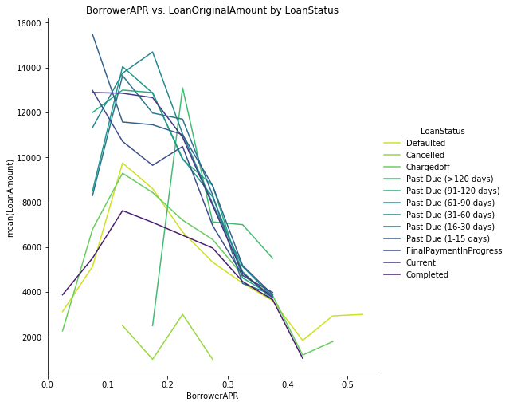

```python
# Lineplot of BorrowerAPR and LoanOriginalAmount using LoanStatus as hue
bin_edges = np.arange(0, loan['BorrowerAPR'].max()+0.05, 0.05)
g = sb.FacetGrid(data = loan, hue = 'LoanStatus',size=7,palette='viridis_r');
g.map(mean_poly, "BorrowerAPR", "LoanOriginalAmount", bins = bin_edges);
g.set_ylabels('mean(LoanAmount)');
g.add_legend();
plt.title('BorrowerAPR vs. LoanOriginalAmount by LoanStatus');
```

## Conclusion

> I extended my investigation of BorrowerAPR and LoanStatus by looking at the impact various features like ProsperRating, LoanAmount and Term had on them.
> 1. PropserRating is a very important criteria when it comes to deciding the BorrowerAPR and LoanAmount. Higher the ProsperRating higher the LoanAmount (more investors) and lower the BorrowerAPR (and BorrowerRate).
> 2. Term also affects BorrowerAPR and LoanAmount. Longer the length of the Term higher the LoanAmount and lower the BorrowerAPR.
> 3. LoanStatus is not dependent on one or two features. LoanStatus is affected by the combination of features like ProsperRating, BorrowerAPR, BorrowerRate, LoanAmount and Term. All these features affect the outcome of a loan. Loans with low LoanAmount cane be waived off by lenders. Loans withs good PrsoperRating are less in numbers in deliquent(past due) status. Loans with short terms are more likely to become deliquent(past due) in status and so on.